# Part I - (LOAN DATA FROM PROSPER)

## by (RICHARD MADU)

- Introduction
- Perliminary Wrangling
- Univariate Exploration of Data
- Bivariate Exploration of Data
- Multivariate Exploration of Data
- Conclusions

## Introduction

> This data set contains 113,937 loans with 81 variables on each loan, including loan amount, borrower rate (or interest rate), current loan status, borrower income, and many others.

```python
# import all packages and set plots to be embedded inline
import numpy as np
import pandas as pd
import matplotlib.pyplot as plt
import seaborn as sb

%matplotlib inline
```

```python
# import the data

prosper_loan = pd.read_csv('prosperLoanData.csv')
```

```python
# exploring  the dataset
print(prosper_loan.shape)
prosper_loan.head()
```

```
(113937, 81)
```

|  | ListingKey | ListingNumber | ListingCreationDate | CreditGrade | Term | LoanStatus | ClosedDate | BorrowerAPR | BorrowerRate | LenderYield | ... | LP_ServiceFees | LP_CollectionFees | LP_GrossPrincipalLoss | LP_NetPrincipalLoss | LP_NonPrincipalRecoverypayments | PercentFunded | Recommendations | InvestmentFromFriendsCount | InvestmentFromFriendsAmount | Investors |
| --- | --- | --- | --- | --- | --- | --- | --- | --- | --- | --- | --- | --- | --- | --- | --- | --- | --- | --- | --- | --- | --- |
| 0 | 1021339766868145413AB3B | 193129 | 2007-08-26 19:09:29.263000000 | C | 36 | Completed | 2009-08-14 00:00:00 | 0.16516 | 0.1580 | 0.1380 | ... | -133.18 | 0.0 | 0.0 | 0.0 | 0.0 | 1.0 | 0 | 0 | 0.0 | 258 |
| 1 | 10273602499503308B223C1 | 1209647 | 2014-02-27 08:28:07.900000000 | NaN | 36 | Current | NaN | 0.12016 | 0.0920 | 0.0820 | ... | 0.00 | 0.0 | 0.0 | 0.0 | 0.0 | 1.0 | 0 | 0 | 0.0 | 1 |
| 2 | 0EE9337825851032864889A | 81716 | 2007-01-05 15:00:47.090000000 | HR | 36 | Completed | 2009-12-17 00:00:00 | 0.28269 | 0.2750 | 0.2400 | ... | -24.20 | 0.0 | 0.0 | 0.0 | 0.0 | 1.0 | 0 | 0 | 0.0 | 41 |
| 3 | 0EF5356002482715299901A | 658116 | 2012-10-22 11:02:35.010000000 | NaN | 36 | Current | NaN | 0.12528 | 0.0974 | 0.0874 | ... | -108.01 | 0.0 | 0.0 | 0.0 | 0.0 | 1.0 | 0 | 0 | 0.0 | 158 |
| 4 | 0F023589499656230C5E3E2 | 909464 | 2013-09-14 18:38:39.097000000 | NaN | 36 | Current | NaN | 0.24614 | 0.2085 | 0.1985 | ... | -60.27 | 0.0 | 0.0 | 0.0 | 0.0 | 1.0 | 0 | 0 | 0.0 | 20 |

5 rows × 81 columns

```python
prosper_loan.info()
```

```
<class 'pandas.core.frame.DataFrame'>
RangeIndex: 113937 entries, 0 to 113936
Data columns (total 81 columns):
ListingKey                             113937 non-null object
ListingNumber                          113937 non-null int64
ListingCreationDate                    113937 non-null object
CreditGrade                            28953 non-null object
Term                                   113937 non-null int64
LoanStatus                             113937 non-null object
ClosedDate                             55089 non-null object
BorrowerAPR                            113912 non-null float64
BorrowerRate                           113937 non-null float64
LenderYield                            113937 non-null float64
EstimatedEffectiveYield                84853 non-null float64
EstimatedLoss                          84853 non-null float64
EstimatedReturn                        84853 non-null float64
ProsperRating (numeric)                84853 non-null float64
ProsperRating (Alpha)                  84853 non-null object
ProsperScore                           84853 non-null float64
ListingCategory (numeric)              113937 non-null int64
BorrowerState                          108422 non-null object
Occupation                             110349 non-null object
EmploymentStatus                       111682 non-null object
EmploymentStatusDuration               106312 non-null float64
IsBorrowerHomeowner                    113937 non-null bool
CurrentlyInGroup                       113937 non-null bool
GroupKey                               13341 non-null object
DateCreditPulled                       113937 non-null object
CreditScoreRangeLower                  113346 non-null float64
CreditScoreRangeUpper                  113346 non-null float64
FirstRecordedCreditLine                113240 non-null object
CurrentCreditLines                     106333 non-null float64
OpenCreditLines                        106333 non-null float64
TotalCreditLinespast7years             113240 non-null float64
OpenRevolvingAccounts                  113937 non-null int64
OpenRevolvingMonthlyPayment            113937 non-null float64
InquiriesLast6Months                   113240 non-null float64
TotalInquiries                         112778 non-null float64
CurrentDelinquencies                   113240 non-null float64
AmountDelinquent                       106315 non-null float64
```

[output cut: 31 more lines]

```
LP_CustomerPayments                    113937 non-null float64
LP_CustomerPrincipalPayments           113937 non-null float64
LP_InterestandFees                     113937 non-null float64
LP_ServiceFees                         113937 non-null float64
LP_CollectionFees                      113937 non-null float64
LP_GrossPrincipalLoss                  113937 non-null float64
LP_NetPrincipalLoss                    113937 non-null float64
LP_NonPrincipalRecoverypayments        113937 non-null float64
PercentFunded                          113937 non-null float64
Recommendations                        113937 non-null int64
InvestmentFromFriendsCount             113937 non-null int64
InvestmentFromFriendsAmount            113937 non-null float64
Investors                              113937 non-null int64
dtypes: bool(3), float64(50), int64(11), object(17)
memory usage: 68.1+ MB
```

## Preliminary Wrangling

```python
# extract the variables of interest in the dataset

df = prosper_loan.loc[:, prosper_loan.columns.intersection(['LoanStatus','ProsperScore','EmploymentStatus','BorrowerAPR','ProsperRating (Alpha)','CreditGrade','Term',
                                               'LenderYield','MonthlyLoanPayment', 'IsBorrowerHomeowner', 'LoanOriginalAmount', 'StatedMonthlyIncome'])]
```

```python
df.info()
```

```
<class 'pandas.core.frame.DataFrame'>
RangeIndex: 113937 entries, 0 to 113936
Data columns (total 12 columns):
CreditGrade              28953 non-null object
Term                     113937 non-null int64
LoanStatus               113937 non-null object
BorrowerAPR              113912 non-null float64
LenderYield              113937 non-null float64
ProsperRating (Alpha)    84853 non-null object
ProsperScore             84853 non-null float64
EmploymentStatus         111682 non-null object
IsBorrowerHomeowner      113937 non-null bool
StatedMonthlyIncome      113937 non-null float64
LoanOriginalAmount       113937 non-null int64
MonthlyLoanPayment       113937 non-null float64
dtypes: bool(1), float64(5), int64(2), object(4)
memory usage: 9.7+ MB
```

## Univariate Exploration

### WHAT IS THE MOST POPULAR LOAN STATUS?

```python
#create a function for the label to avoid repetition of codes
def label (x,y,z):
    """
    Args:
    x(str): x-axis title
    y(str): y-axis title
    z(str): main title

    returns:
    None

    """

    plt.xlabel(x)
    plt.ylabel(y)
    plt.title(z)
    plt.show()
```

```python
# EXPLORE THE LOAN STATUS
df['LoanStatus'].unique()
```

[output not shown]

we can easily categorize the Loan Staues to just Completed, Current, Past Due, Defaulted, Chargedoff, Cancelled and Final Pay forgoing the delinquency bucket

```python
df['LoanStatus'] = df['LoanStatus'].str.split('(').str[0]
```

```python
df['LoanStatus'].unique()
```

```
array(['Completed', 'Current', 'Past Due ', 'Defaulted', 'Chargedoff',
       'Cancelled', 'FinalPaymentInProgress'], dtype=object)
```

```python
# get the order at which the bars are going to be arranged
stat_count = df['LoanStatus'].value_counts()
stat_count
stat_order = stat_count.index
stat_order
```

```
Index(['Current', 'Completed', 'Chargedoff', 'Defaulted', 'Past Due ',
       'FinalPaymentInProgress', 'Cancelled'],
      dtype='object')
```

```python
# select the color pallete
base_color = sb.color_palette()[0]
```

```python
# scale the data to be percent
n_loan = df['LoanStatus'].value_counts().sum()
max_count = stat_count[0]
max_prop = max_count / n_loan
max_prop
```

```
0.4965551137909546
```

```python
# set the proportions and tick names
tick_props = np.arange(0,max_prop,0.05)
tick_names = ['{:0.2f}'.format(v) for v in tick_props]
```

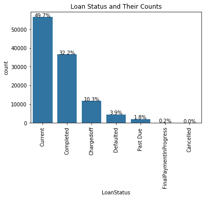

```python
# create a bar chart
sb.countplot(data = df, x = 'LoanStatus', color = base_color, order = stat_order)
stat_count = df['LoanStatus'].value_counts()

# get the current tick locations and labels
locs, labels = plt.xticks(rotation=90)
plt.title('Loan Status and Their Counts')

# loop through each pair of locations and labels
for loc, label in zip(locs, labels):

    # get the text property for the label to get the correct count
    count = stat_count[label.get_text()]
    pct_string = '{:0.1f}%'.format(100*count/n_loan)

    # print the annotation just below the top of the bar
    plt.text(loc, count+2, pct_string, ha = 'center', color = 'black')
```

49.7% OF ALL LOAN STATUSES ARE CURRENT. MAKING IT THE MOST POPULAR LOAN STATUS.

### ARE THERE MORE HOME OWNERS THAN NON HOME OWNERS?

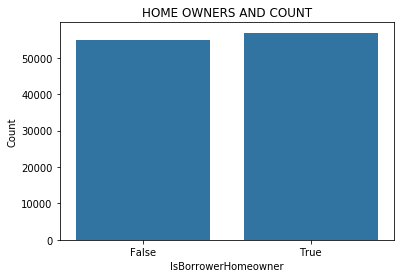

```python
# PLOT A BAR CHART
sb.countplot(data = df, x = 'IsBorrowerHomeowner', color = base_color)
label('IsBorrowerHomeowner', 'Count','HOME OWNERS AND COUNT')
```

THERE ARE SLIGHTLY MORE HOME OWNERS THAN NON HOME OWNERS

### WHAT IS THE MOST POPULAR EMPLOYMENT?

```python
# explore the Employment Status
df['EmploymentStatus'].unique()
```

```
array(['Self-employed', 'Employed', 'Not available', 'Full-time', 'Other',
       nan, 'Not employed', 'Part-time', 'Retired'], dtype=object)
```

```python
#remove the nan values
df = df[df['EmploymentStatus'].notna()]
```

Here I categorized the Employment Status to just employed, self-employed,unemployed, retired and others

```python
df['EmploymentStatus'] = df['EmploymentStatus'].replace(['Full-time','Part-time'],'Employed')
df['EmploymentStatus'] = df['EmploymentStatus'].replace(['Not available','Other'],'Others')
df['EmploymentStatus'] = df['EmploymentStatus'].replace(['Not employed'],'Unemployed')
```

```python
df['EmploymentStatus'].unique()
```

```
array(['Self-employed', 'Employed', 'Others', 'Unemployed', 'Retired'],
      dtype=object)
```

```python
#set the order of the bars in the bar chart
emp_order = df['EmploymentStatus'].value_counts().index
emp_order
```

```
Index(['Employed', 'Others', 'Self-employed', 'Unemployed', 'Retired'], dtype='object')
```

```python
# scale the xticks to be the propotions
emp_count = df['EmploymentStatus'].value_counts()
n_emp =df['EmploymentStatus'].value_counts().sum()
max_count_emp = emp_count[0]
max_prop_emp = max_count_emp / n_emp
max_prop_emp
```

```
0.8485252771261259
```

```python
# set ticks
tick_props = np.arange(0,max_prop_emp,0.09)
tick_names = ['{:0.2f}'.format(v) for v in tick_props]
```

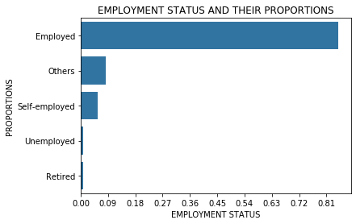

```python
# plot a chart

sb.countplot(data = df, y = 'EmploymentStatus', color = base_color, order = emp_order)

plt.xticks(tick_props * n_emp, tick_names)
label('EMPLOYMENT STATUS','PROPORTIONS','EMPLOYMENT STATUS AND THEIR PROPORTIONS')
```

THE MOST POPULAR EMPLOYMENT STATUS IS EMPLOYED

### WHAT IS THE MOST POPULAR LOAN TERM?

```python
# order the bar chart
term_order = df['Term'].value_counts().index
term_order
```

```
Int64Index([36, 60, 12], dtype='int64')
```

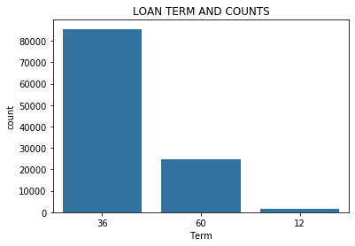

```python
# CREATE A COUNT PLOT OF THE LOAN TERMS
sb.countplot(data = df, x = 'Term', color = base_color, order = term_order)
plt.title('LOAN TERM AND COUNTS');
```

THE MOST POPULAR LOAN TERM IS 36 MONTHS(3 YEARS) AND THE LEAST POPULAR LOAN TERM IS 12 MONTHS (1 YEAR)

## WHAT IS THE DISTRIBUTION OF THE BORROWER'S APR?

```python
# BEFORE PLOTTING A HISTOGRM I WOULD SET THE BINS
bins = np.arange(0,df['BorrowerAPR'].max()+0.1,0.05)
```

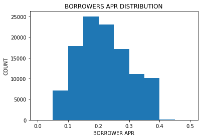

```python
# PLOT THE HISTOGRAM
plt.hist(data = df, x = 'BorrowerAPR', bins = bins);
label('BORROWER APR', 'COUNT','BORROWERS APR DISTRIBUTION')
```

## WHAT IS THE DISTRIBUTION OF THE CUSTOMER'S RISK SCORE (PROSPER SCORE)

```python
# SET THE ORDER OF THE BARS
score_order = df['ProsperScore'].value_counts().index
score_order
```

```
Float64Index([4.0, 6.0, 8.0, 7.0, 5.0, 3.0, 9.0, 2.0, 10.0, 11.0, 1.0], dtype='float64')
```

From the meta the scores is suppose to be from 1 - 10 and we have an eleven. Lets explore the data with prosper score of 10 and 11 and see if there is any similarities

```python
# Exploring the data with prosper score of 10
df[(df['ProsperScore'] == 10)].head(10)
```

|  | CreditGrade | Term | LoanStatus | BorrowerAPR | LenderYield | ProsperRating (Alpha) | ProsperScore | EmploymentStatus | IsBorrowerHomeowner | StatedMonthlyIncome | LoanOriginalAmount | MonthlyLoanPayment |
| --- | --- | --- | --- | --- | --- | --- | --- | --- | --- | --- | --- | --- |
| 5 | NaN | 60 | Current | 0.15425 | 0.1214 | B | 10.0 | Employed | True | 8333.333333 | 15000 | 342.37 |
| 33 | NaN | 36 | Completed | 0.08191 | 0.0685 | AA | 10.0 | Employed | False | 13083.333333 | 16000 | 500.28 |
| 49 | NaN | 60 | Current | 0.11695 | 0.0849 | A | 10.0 | Employed | True | 7458.333333 | 25000 | 524.92 |
| 81 | NaN | 60 | Current | 0.12216 | 0.0900 | AA | 10.0 | Employed | False | 10000.000000 | 25000 | 531.18 |
| 99 | NaN | 60 | Current | 0.10878 | 0.0769 | AA | 10.0 | Others | False | 3750.000000 | 10000 | 206.08 |
| 126 | NaN | 36 | Current | 0.13799 | 0.0999 | A | 10.0 | Employed | True | 4333.333333 | 14000 | 458.28 |
| 147 | NaN | 36 | Completed | 0.09191 | 0.0612 | AA | 10.0 | Employed | False | 4169.333333 | 2200 | 68.05 |
| 174 | NaN | 36 | Current | 0.09988 | 0.0764 | AA | 10.0 | Employed | False | 7083.333333 | 3600 | 113.88 |
| 199 | NaN | 36 | Current | 0.11599 | 0.0779 | A | 10.0 | Employed | True | 9583.333333 | 13000 | 412.13 |
| 205 | NaN | 36 | Current | 0.07922 | 0.0559 | AA | 10.0 | Employed | True | 13750.000000 | 10000 | 306.90 |

```python
# Exploring the data with prosper score of 11
df[(df['ProsperScore'] == 11)].head(10)
```

|  | CreditGrade | Term | LoanStatus | BorrowerAPR | LenderYield | ProsperRating (Alpha) | ProsperScore | EmploymentStatus | IsBorrowerHomeowner | StatedMonthlyIncome | LoanOriginalAmount | MonthlyLoanPayment |
| --- | --- | --- | --- | --- | --- | --- | --- | --- | --- | --- | --- | --- |
| 9 | NaN | 36 | Current | 0.07620 | 0.0529 | AA | 11.0 | Employed | True | 3333.333333 | 10000 | 305.54 |
| 69 | NaN | 60 | Current | 0.13636 | 0.1039 | A | 11.0 | Self-employed | True | 2700.000000 | 9000 | 197.44 |
| 158 | NaN | 36 | Current | 0.09469 | 0.0709 | AA | 11.0 | Employed | False | 6666.666667 | 5500 | 172.58 |
| 224 | NaN | 36 | Current | 0.13799 | 0.0999 | A | 11.0 | Employed | True | 33333.333333 | 30000 | 982.02 |
| 236 | NaN | 36 | Current | 0.06726 | 0.0505 | AA | 11.0 | Employed | True | 4083.333333 | 9000 | 274.00 |
| 277 | NaN | 60 | Current | 0.15868 | 0.1255 | B | 11.0 | Employed | False | 6833.333333 | 20000 | 460.71 |
| 476 | NaN | 60 | Current | 0.14528 | 0.1124 | B | 11.0 | Employed | False | 13083.333333 | 15000 | 335.49 |
| 491 | NaN | 60 | Current | 0.17327 | 0.1400 | B | 11.0 | Employed | True | 8166.666667 | 25000 | 594.75 |
| 532 | NaN | 36 | Current | 0.13799 | 0.0999 | A | 11.0 | Others | True | 10833.333333 | 10000 | 327.34 |
| 554 | NaN | 60 | Current | 0.09367 | 0.0709 | AA | 11.0 | Employed | True | 15000.000000 | 20000 | 406.39 |

From the data exploration we that ProsperRating of the data with prosperscore of 10 and 11 are similar so I will change the 11 score to 10

```python
# replace prosper score of 11 to 10

df['ProsperScore'] = df['ProsperScore'].replace([11],10)
df['ProsperScore'].unique()
```

```
array([nan,  7.,  9.,  4., 10.,  2.,  8.,  5.,  3.,  6.,  1.])
```

```python
# SET THE ORDER OF THE BARS
score_order = df['ProsperScore'].value_counts().index
score_order
```

```
Float64Index([4.0, 6.0, 8.0, 7.0, 5.0, 3.0, 9.0, 10.0, 2.0, 1.0], dtype='float64')
```

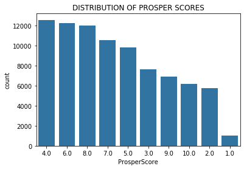

```python
#plot the bar chart
sb.countplot(data = df, x = 'ProsperScore', color = base_color, order= score_order)
plt.title('DISTRIBUTION OF PROSPER SCORES');
```

Most of the costumers have a 4 score which is represent a moderate risk

## BIVARIATE EXPLORATION OF DATA

### WHAT IS THE RELATIONSHIP BETWEEN THE BORROWER'S APR AND THE LENDER'S YIELD

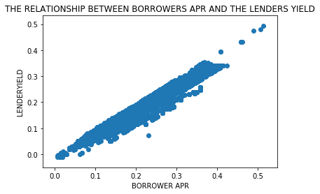

```python
# PLOT A SCATTER PLOT THAT SHOWS THE RELATIONSHIP BETWEEN BORROWERS APR AND THE LENDER'S YIELD
plt.scatter(data = prosper_loan, x = 'BorrowerAPR', y ='LenderYield')
label('BORROWER APR', 'LENDERYIELD','THE RELATIONSHIP BETWEEN BORROWERS APR AND THE LENDERS YIELD')
```

### WHAT IS RELATIONSHIP BETWEEN MONTHLY LAON PAYMENT AND THE LENDER YIELD?

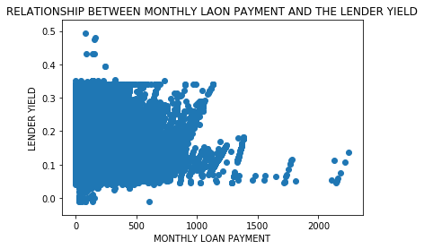

```python
# PLOT A SCATTERPLOT THAT SHOW TTHE RELATIONSHIP BETWEEN MONTHLY LAON PAYMENT AND THE LENDER YIELD
plt.scatter(data = prosper_loan, x = 'MonthlyLoanPayment', y ='LenderYield')
label('MONTHLY LOAN PAYMENT', 'LENDER YIELD', 'RELATIONSHIP BETWEEN MONTHLY LAON PAYMENT AND THE LENDER YIELD');
```

THERE IS NO CLEAR RELATIONSHIP SHOW I WOULD TAKE A SAMPLE AND PLOT THE SCATTER PLOT TO SEE IF I CAN SEE A TREND

```python
# take a sample of 200
sample = np.random.choice(df.shape[0], 200, replace = False)
df_samp = df.loc[sample]
```

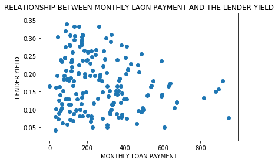

```python
# Plot the scatter plot again
plt.scatter(data = df_samp, x = 'MonthlyLoanPayment', y ='LenderYield')
label('MONTHLY LOAN PAYMENT', 'LENDER YIELD', 'RELATIONSHIP BETWEEN MONTHLY LAON PAYMENT AND THE LENDER YIELD');
```

## HOW HOME OWNERS ARE SPREAD ACROSS THE DIFFERENT EMPLOYMENT STATUS

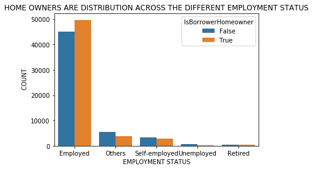

```python
# PLOT A CLUSTER BAR CHART TO INVESTIGATING THIS
sb.countplot(data = df, x = 'EmploymentStatus', hue = 'IsBorrowerHomeowner',order = emp_order )
label('EMPLOYMENT STATUS',' COUNT', 'HOME OWNERS ARE DISTRIBUTION ACROSS THE DIFFERENT EMPLOYMENT STATUS')
```

ONLY THE EMPLOYED GROUP HAS MORE HOME OWNERS THAN NON HOME OWNER

## DO HOME OWNERS HAVE BETTER CREDIT RISK

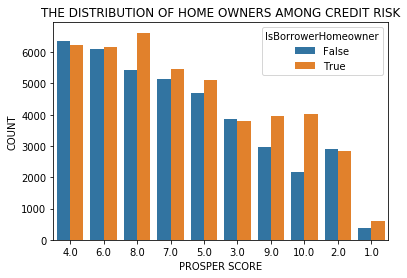

```python
# PLOT A CLUSTER BAR CHART THAT SHOWS THE DISTRIBUTION OF HOME OWNERS AMONG CREDIT RISK

sb.countplot(data = df, x = 'ProsperScore', hue = 'IsBorrowerHomeowner', order= score_order)
label('PROSPER SCORE', 'COUNT', 'THE DISTRIBUTION OF HOME OWNERS AMONG CREDIT RISK')
```

## WHAT IS THE MOST POPULAR MONTHLY LOAN PAYMENT AND THEIR LOAN AMOUNT

```python
# SET THE BINS FOR THE 2D HISTOGRAM
bins_x = np.arange(0,df['MonthlyLoanPayment'].max() + 100, 250)
bins_y = np.arange(0, df['LoanOriginalAmount'].max() +1000, 2500)
```

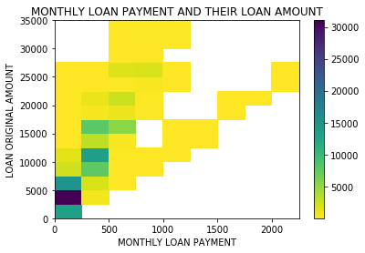

```python
#PLOT THE 2D HISTOGRAM
plt.subplot(1, 1, 1)
plt.hist2d(data = prosper_loan, x = 'MonthlyLoanPayment', y = 'LoanOriginalAmount', cmin=0.5, cmap='viridis_r',  bins = [bins_x, bins_y])
plt.colorbar()
label('MONTHLY LOAN PAYMENT', 'LOAN ORIGINAL AMOUNT','MONTHLY LOAN PAYMENT AND THEIR LOAN AMOUNT')
```

MOST PEOPLE TAKE LOAN IN THE RANGE OF 2500 - 5000 AND THEIR MONTHLY LOAN PAYMENT IS BETWEEN 0-250

## HOW MUCH DO PEOPLE OF DIFFERENT EMPLOYMENT STATUS TAKE AS LOAN?

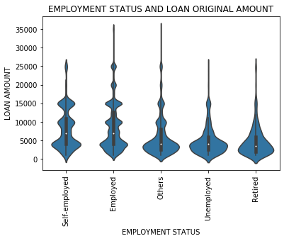

```python
#CREATE A VIOLIN PLOT
sb.violinplot(data=df, y='LoanOriginalAmount', x='EmploymentStatus', color = base_color)
plt.xticks(rotation = 90)
label('EMPLOYMENT STATUS','LOAN AMOUNT', 'EMPLOYMENT STATUS AND LOAN ORIGINAL AMOUNT')
```

PEOPLE IN THE UNEMPLOYED, RETIRED AND OTHERS GROUPS TAKE LOANS OF LESSER AMOUNT (IN THE REGION OF 2500-5000) THAN THE EMPLOYED AND SELF-EMPLOYED

### WHAT IS THE RELATIONSHIP BETWEEN THE INCOME AND AMOUNT OF LOAN THE TAKE

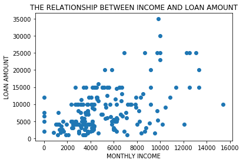

```python
# CREATE A SCATTER PLOT
plt.scatter(data = df_samp, x = 'StatedMonthlyIncome', y = 'LoanOriginalAmount')
label('MONTHLY INCOME', 'LOAN AMOUNT', 'THE RELATIONSHIP BETWEEN INCOME AND LOAN AMOUNT')
```

FROM THE PLOT ABOVE WE CAN SEE THAT THERE IS A POSITIVE RELATIONSHIP BETWEEN INCOME AND THE AMOUNT OF LOAN PEOPLE TAKE

## MULTIVARIATE EXPLORATION OF DATA

### WHAT IS RELATIONSHIP BETWEEN LOAN AMOUNT AND MONTHLY LOAN PAYMENT FOR EACH LOAN TERMS?

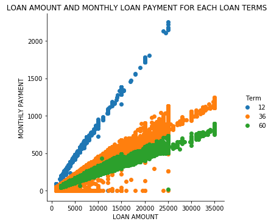

```python
# create a color palette
g = sb.FacetGrid(data = df, hue = 'Term', size = 5)
g.map(plt.scatter, 'LoanOriginalAmount', 'MonthlyLoanPayment')
g.add_legend()
label('LOAN AMOUNT', 'MONTHLY PAYMENT',' LOAN AMOUNT AND MONTHLY LOAN PAYMENT FOR EACH LOAN TERMS')
```

LOANS OF LESSER TERM HAVE A HIGHER MONTHLY PAYMENT. THEY ALSO HAVE A LOW LOAN AMOUNT

### WHAT IS THE RELATIONSHIP BETWEEN THE BORROWER APR AND MONTHLY PAYMENT FOR HOME OWNERS AND NON HOME OWNERS

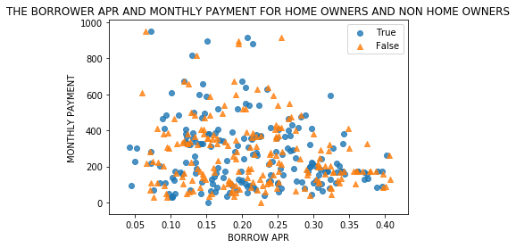

```python
#set the makers
markers = [['True', 'o'],
           ['False', '^']]
# set the non positional encoding
for c, r in markers:
    plot_data = df_samp.loc[df_samp['IsBorrowerHomeowner'] == c]
    sb.regplot(data = df_samp, x = 'BorrowerAPR', y = 'MonthlyLoanPayment',x_jitter = 0.04, fit_reg = False, marker = r)
plt.legend(['True','False'])
label('BORROW APR','MONTHLY PAYMENT','THE BORROWER APR AND MONTHLY PAYMENT FOR HOME OWNERS AND NON HOME OWNERS')
```

# CONCLUSION

### Results:

Our results shows that:

> 49.7% OF ALL LOAN STATUSES ARE CURRENT. MAKING IT THE MOST POPULAR LOAN STATUS.

> THERE ARE SLIGHTLY MORE HOME OWNERS THAN NON HOME OWNERS

> MOST OF THE BORROWERS ARE EMPLOYED

> THE MOST POPULAR LOAN TERM IS 36 MONTHS(3 YEARS) AND THE LEAST POPULAR LOAN TERM IS 12 MONTHS (1 YEAR)

> Most of the costumers have a 4 score which is represent a moderate risk

> ONLY THE EMPLOYED GROUP HAS MORE HOME OWNERS THAN NON HOME OWNER

> MOST PEOPLE TAKE LOAN IN THE RANGE OF 2500 - 5000 AND THEIR MONTHLY LOAN PAYMENT IS BETWEEN 0-250

> PEOPLE IN THE UNEMPLOYED, RETIRED AND OTHERS GROUPS TAKE LOANS OF LESSER AMOUNT (IN THE REGION OF 2500-5000) THAN THE EMPLOYED AND SELF-EMPLOYED

> THERE IS A POSITIVE RELATIONSHIP BETWEEN INCOME AND THE AMOUNT OF LOAN PEOPLE TAKE

> LOANS OF LESSER TERM HAVE A HIGHER MONTHLY PAYMENT. THEY ALSO HAVE A LOW LOAN AMOUNT

### LIMITATION

> Only describtive statistics are used in this analysis. Therefore we did not create any hypothesis or inference with the data

> Another consequence of using descriptive statistics is that we don't know the extent of the correlationships

> We can not use this analysis to make generalization